# Summary and Plotting Utilities

This notebook demonstrates the summary and plotting utilities available for `stochtree` models in Python.

We begin by loading all necessary libraries.

```python
import numpy as np
import matplotlib.pyplot as plt
from stochtree import (
    BARTModel,
    BCFModel,
    plot_parameter_trace
)
```

import numpy as np import matplotlib.pyplot as plt from stochtree import ( BARTModel, BCFModel, plot_parameter_trace )

And set a random seed for reproducibility.

```python
random_seed = 1234
rng = np.random.default_rng(random_seed)
```

random_seed = 1234 rng = np.random.default_rng(random_seed)

## Supervised Learning

We begin with the supervised learning use case served by the `BARTModel` class.

Below we simulate a simple regression dataset.

```python
# Generate covariates and basis
n = 1000
p_X = 10
p_W = 1
X = rng.uniform(0, 1, (n, p_X))
W = rng.uniform(0, 1, (n, p_W))

# Define the outcome mean function
def outcome_mean(X, W):
    return np.where(
        (X[:, 0] >= 0.0) & (X[:, 0] < 0.25),
        -7.5 * W[:, 0],
        np.where(
            (X[:, 0] >= 0.25) & (X[:, 0] < 0.5),
            -2.5 * W[:, 0],
            np.where((X[:, 0] >= 0.5) & (X[:, 0] < 0.75),
                2.5 * W[:, 0],
                7.5 * W[:, 0]),
        ),
    )


# Generate outcome
epsilon = rng.normal(0, 1, n)
y = outcome_mean(X, W) + epsilon
```

# Generate covariates and basis n = 1000 p_X = 10 p_W = 1 X = rng.uniform(0, 1, (n, p_X)) W = rng.uniform(0, 1, (n, p_W)) # Define the outcome mean function def outcome_mean(X, W): return np.where( (X[:, 0] >= 0.0) & (X[:, 0] < 0.25), -7.5 * W[:, 0], np.where( (X[:, 0] >= 0.25) & (X[:, 0] < 0.5), -2.5 * W[:, 0], np.where((X[:, 0] >= 0.5) & (X[:, 0] < 0.75), 2.5 * W[:, 0], 7.5 * W[:, 0]), ), ) # Generate outcome epsilon = rng.normal(0, 1, n) y = outcome_mean(X, W) + epsilon

Now we fit a simple BART model to the data

```python
bart_model = BARTModel()
general_params = {"num_chains": 3}
bart_model.sample(
    X_train=X,
    y_train=y,
    leaf_basis_train=W,
    num_gfr=10,
    num_mcmc=1000,
    general_params=general_params,
)
```

bart_model = BARTModel() general_params = {"num_chains": 3} bart_model.sample( X_train=X, y_train=y, leaf_basis_train=W, num_gfr=10, num_mcmc=1000, general_params=general_params, )

We obtain a high level summary of the BART model by running `print()`

```python
print(bart_model)
```

print(bart_model)

```
BARTModel run with mean forest, global error variance model, and mean forest leaf scale model
Outcome was modeled as gaussian with a leaf regression prior with 1 bases for the mean forest
Outcome was standardized
The sampler was run for 10 GFR iterations, with 3 chains of 0 burn-in iterations and 1000 MCMC iterations, retaining every iteration (i.e. no thinning)
```

For a more detailed summary (including the information above), we use the `summary()` method of `BARTModel`.

```python
print(bart_model.summary())
```

print(bart_model.summary())

```
BART Model Summary:
-------------------
BARTModel run with mean forest, global error variance model, and mean forest leaf scale model
Outcome was modeled as gaussian with a leaf regression prior with 1 bases for the mean forest
Outcome was standardized
The sampler was run for 10 GFR iterations, with 3 chains of 0 burn-in iterations and 1000 MCMC iterations, retaining every iteration (i.e. no thinning)

Summary of sigma^2 posterior: 3000 samples, mean = 0.928, standard deviation = 0.048, quantiles:
    2.5%: 0.833
   10.0%: 0.869
   25.0%: 0.895
   50.0%: 0.926
   75.0%: 0.960
   90.0%: 0.991
   97.5%: 1.025
Summary of leaf scale posterior: 3000 samples, mean = 0.008, standard deviation = 0.001, quantiles:
    2.5%: 0.005
   10.0%: 0.006
   25.0%: 0.007
   50.0%: 0.008
   75.0%: 0.008
   90.0%: 0.009
   97.5%: 0.010
Summary of in-sample posterior mean predictions:
1000 observations, mean = 0.221, standard deviation = 3.231, quantiles:
    2.5%: -6.764
   10.0%: -4.289
   25.0%: -1.713
   50.0%: 0.358
   75.0%: 2.012
   90.0%: 4.566
   97.5%: 6.701

None
```

Finally, we can use the `plot_parameter_trace` utility function to make quick traceplots of any parametric terms, which in this case involves the global error scale $\sigma^2$ and the leaf scale $\sigma^2_{\ell}$

```python
ax = plot_parameter_trace(bart_model, term="global_error_scale")
plt.show()
```

ax = plot_parameter_trace(bart_model, term="global_error_scale") plt.show()

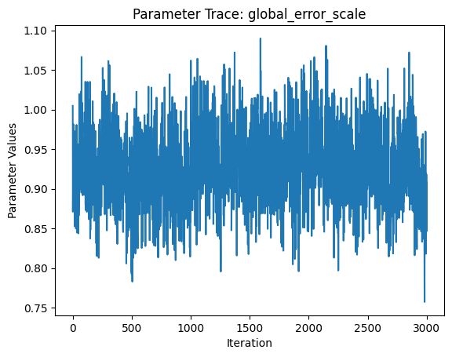

```python
ax = plot_parameter_trace(bart_model, term="leaf_scale")
plt.show()
```

ax = plot_parameter_trace(bart_model, term="leaf_scale") plt.show()

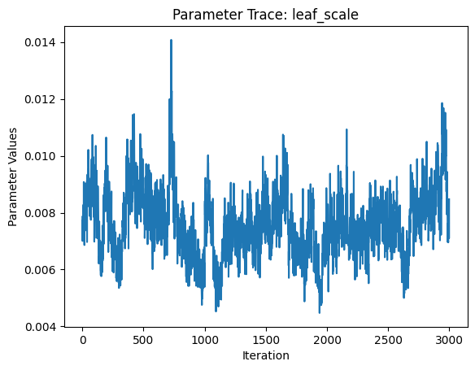

For finer-grained control over which parameters to plot, we can also use the `extract_parameter()` method to pull the posterior distribution of any valid model term (e.g., global error scale $\sigma^2$, leaf scale $\sigma^2_{\ell}$, in-sample mean function predictions `y_hat_train`) and then plot any subset or transformation of these values.

```python
y_hat_train_samples = bart_model.extract_parameter("y_hat_train")
obs_index = 0
_, ax = plt.subplots()
ax.plot(y_hat_train_samples[obs_index,:])
ax.set_title(f"Parameter Trace: In-Sample Predictions, Observation {obs_index:d}")
ax.set_xlabel("Iteration")
ax.set_ylabel("Parameter Values")
```

y_hat_train_samples = bart_model.extract_parameter("y_hat_train") obs_index = 0 _, ax = plt.subplots() ax.plot(y_hat_train_samples[obs_index,:]) ax.set_title(f"Parameter Trace: In-Sample Predictions, Observation {obs_index:d}") ax.set_xlabel("Iteration") ax.set_ylabel("Parameter Values")

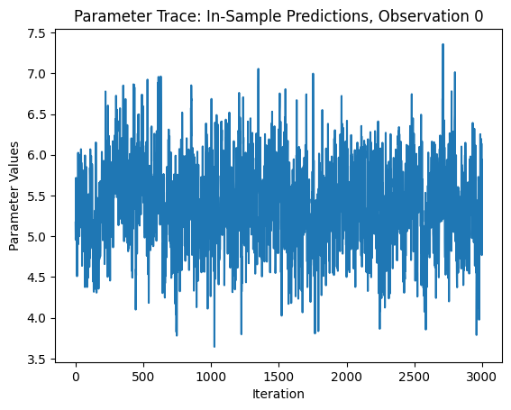

## Causal Inference

We now run the same demo for the causal inference use case served by the `BCFModel` class.

Below we simulate a simple dataset for a causal inference problem with binary treatment and continuous outcome.

```python
# Generate covariates and treatment
n = 1000
p_X = 5
X = rng.uniform(0, 1, (n, p_X))
pi_X = 0.25 + 0.5 * X[:, 0]
Z = rng.binomial(1, pi_X, n).astype(float)

# Define the outcome mean functions (prognostic and treatment effects)
mu_X = pi_X * 5 + 2 * X[:, 2]
tau_X = X[:, 1] * 2 - 1

# Generate outcome
epsilon = rng.normal(0, 1, n)
y = mu_X + tau_X * Z + epsilon
```

# Generate covariates and treatment n = 1000 p_X = 5 X = rng.uniform(0, 1, (n, p_X)) pi_X = 0.25 + 0.5 * X[:, 0] Z = rng.binomial(1, pi_X, n).astype(float) # Define the outcome mean functions (prognostic and treatment effects) mu_X = pi_X * 5 + 2 * X[:, 2] tau_X = X[:, 1] * 2 - 1 # Generate outcome epsilon = rng.normal(0, 1, n) y = mu_X + tau_X * Z + epsilon

Now we fit a simple BCF model to the data

```python
bcf_model = BCFModel()
general_params = {"num_chains": 3}
bcf_model.sample(
    X_train=X,
    Z_train=Z,
    y_train=y,
    propensity_train=pi_X,
    num_gfr=10,
    num_mcmc=1000,
    general_params=general_params,
)
```

bcf_model = BCFModel() general_params = {"num_chains": 3} bcf_model.sample( X_train=X, Z_train=Z, y_train=y, propensity_train=pi_X, num_gfr=10, num_mcmc=1000, general_params=general_params, )

As above, we can `print()` this model for a quick overview

```python
print(bcf_model)
```

print(bcf_model)

```
BCFModel run with prognostic forest, treatment effect forest, global error variance model, prognostic forest leaf scale model, and treatment effect intercept model
Outcome was modeled as gaussian
Treatment was binary and its effect was estimated with adaptive coding
Outcome was standardized
User-provided propensity scores were included in the model
The sampler was run for 10 GFR iterations, with 3 chains of 0 burn-in iterations and 1000 MCMC iterations, retaining every iteration (i.e. no thinning)
```

And we can use the `summary()` method for a more detailed look at sampled model terms

```python
print(bcf_model.summary())
```

print(bcf_model.summary())

```
BCF Model Summary:
------------------
BCFModel run with prognostic forest, treatment effect forest, global error variance model, prognostic forest leaf scale model, and treatment effect intercept model
Outcome was modeled as gaussian
Treatment was binary and its effect was estimated with adaptive coding
Outcome was standardized
User-provided propensity scores were included in the model
The sampler was run for 10 GFR iterations, with 3 chains of 0 burn-in iterations and 1000 MCMC iterations, retaining every iteration (i.e. no thinning)

Summary of sigma^2 posterior: 3000 samples, mean = 0.875, standard deviation = 0.042, quantiles:
    2.5%: 0.796
   10.0%: 0.823
   25.0%: 0.845
   50.0%: 0.874
   75.0%: 0.903
   90.0%: 0.931
   97.5%: 0.960
Summary of prognostic forest leaf scale posterior: 3000 samples, mean = 0.002, standard deviation = 0.000, quantiles:
    2.5%: 0.001
   10.0%: 0.001
   25.0%: 0.001
   50.0%: 0.002
   75.0%: 0.002
   90.0%: 0.002
   97.5%: 0.003
Summary of adaptive coding parameters:
3000 samples, mean (control) = -0.527, mean (treated) = 1.151, standard deviation (control) = 0.324, standard deviation (treated) = 0.318
quantiles (control):
    2.5%: -1.234
   10.0%: -0.943
   25.0%: -0.730
   50.0%: -0.514
   75.0%: -0.305
   90.0%: -0.113
   97.5%: 0.060

quantiles (treated):
    2.5%: 0.546
   10.0%: 0.742
   25.0%: 0.935
```

[output cut: 17 more lines]

```
   50.0%: 3.472
   75.0%: 4.158
   90.0%: 4.768
   97.5%: 5.318
Summary of in-sample posterior mean CATEs:
1000 observations, mean = -0.338, standard deviation = 0.625, quantiles:
    2.5%: -1.391
   10.0%: -1.229
   25.0%: -0.879
   50.0%: -0.256
   75.0%: 0.224
   90.0%: 0.437
   97.5%: 0.612

None
```

Finally, we can also plot parametric terms with `plot_parameter_trace()`

```python
ax = plot_parameter_trace(bcf_model, term="global_error_scale")
plt.show()
```

ax = plot_parameter_trace(bcf_model, term="global_error_scale") plt.show()

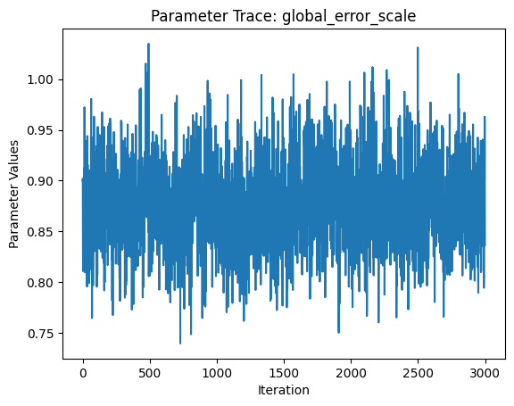

```python
ax = plot_parameter_trace(bcf_model, term="adaptive_coding")
plt.show()
```

ax = plot_parameter_trace(bcf_model, term="adaptive_coding") plt.show()

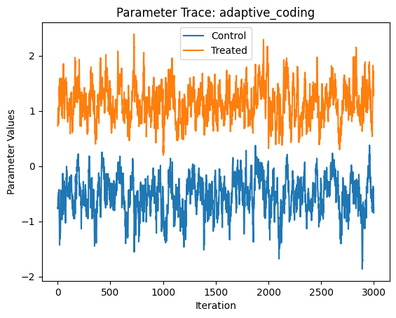

For finer-grained control over which parameters to plot, we can also use the `extract_parameter()` method to pull the posterior distribution of any valid model term (e.g., global error scale $\sigma^2$, prognostic forest leaf scale $\sigma^2_{\mu}$, CATE forest leaf scale $\sigma^2_{\tau}$, adaptive coding parameters $b_0$ and $b_1$ for binary treatment, in-sample mean function predictions `y_hat_train`, in-sample CATE function predictions `tau_hat_train`) and then plot any subset or transformation of these values.

```python
tau_hat_train_samples = bcf_model.extract_parameter("tau_hat_train")
obs_index = 0
_, ax = plt.subplots()
ax.plot(tau_hat_train_samples[obs_index,:])
ax.set_title(f"Parameter Trace: In-Sample CATE Predictions, Observation {obs_index:d}")
ax.set_xlabel("Iteration")
ax.set_ylabel("Parameter Values")
```

tau_hat_train_samples = bcf_model.extract_parameter("tau_hat_train") obs_index = 0 _, ax = plt.subplots() ax.plot(tau_hat_train_samples[obs_index,:]) ax.set_title(f"Parameter Trace: In-Sample CATE Predictions, Observation {obs_index:d}") ax.set_xlabel("Iteration") ax.set_ylabel("Parameter Values")

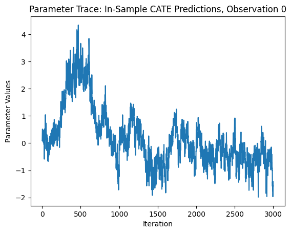